# What my screens are doing to me: an observational log

Ashlee Shum

## The question I started asking myself

I am a final year Computer Science student, which means I’m going to be looking at screens for the rest of my life. This project gave me an excuse to actually *measure* what I’d been suspecting for a while: that “media” is no longer something I do, it’s something I’m always inside.

So for over two weeks I logged every meaningful media session, built on top of the previous observational log for project 2. I recorded what it was, how long it lasted, what time of day, what I was using it for, on what device, and how it left me feeling. The result is the small dataset behind this story, and the five plots below.

## Where my screen time actually goes

For my first plot, I visualised how much time I spent on each respective media type.

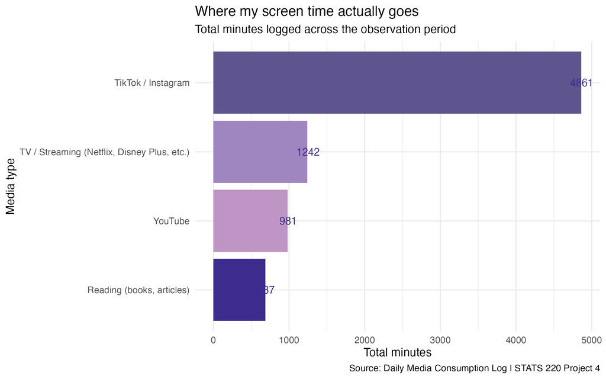

Bar chart showing total minutes per media type across the observation period. Each bar is labelled with its total in minutes, and the categories are sorted from most to least time consumed.

The result was unflattering but unsurprising: short-form video (TikTok and Instagram) absorbs more of my time than any other category, even though each individual session feels small. The “just 10 more minutes” of scrolling really do add up. Reading, the category I *say* I value most, sits noticeably lower than I’d hoped.

## How my media habit moves through the fortnight

The next question was about *patterns* - are there any I can see across the days?

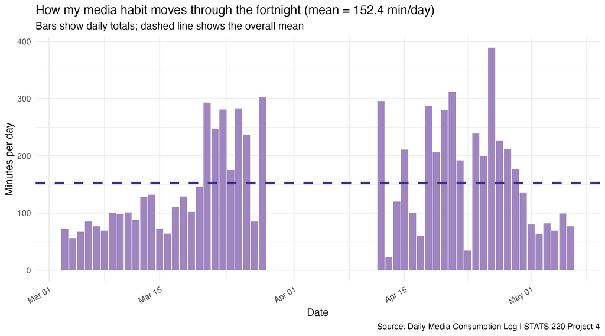

Daily timeline showing total minutes of media consumption per day as purple bars, with a dashed darker line marking the overall daily mean across the observation period.

*Note: there is a period of time where I didn’t log any data, as that was the time we had project 3.*

## When does each kind of media take over?

This is the plot that truly humbled me.

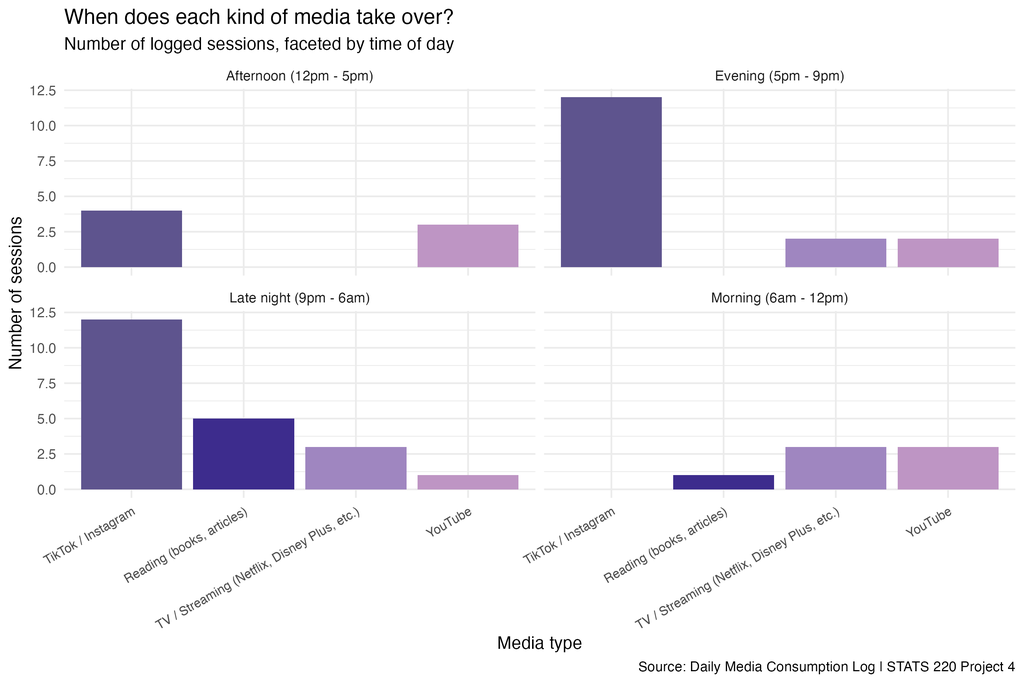

## Each session, and the average for its purpose

This plot is two layers in one frame.

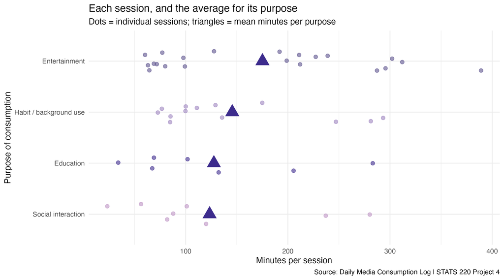

Jittered dot plot showing the duration of every individual session, grouped by the purpose I logged for it. A purple triangle marks the mean session length within each purpose category.

## How does media leave me feeling?

For this project I added a “How did you feel after?” question. The fifth plot pulls out the words that appeared most across those mood entries.

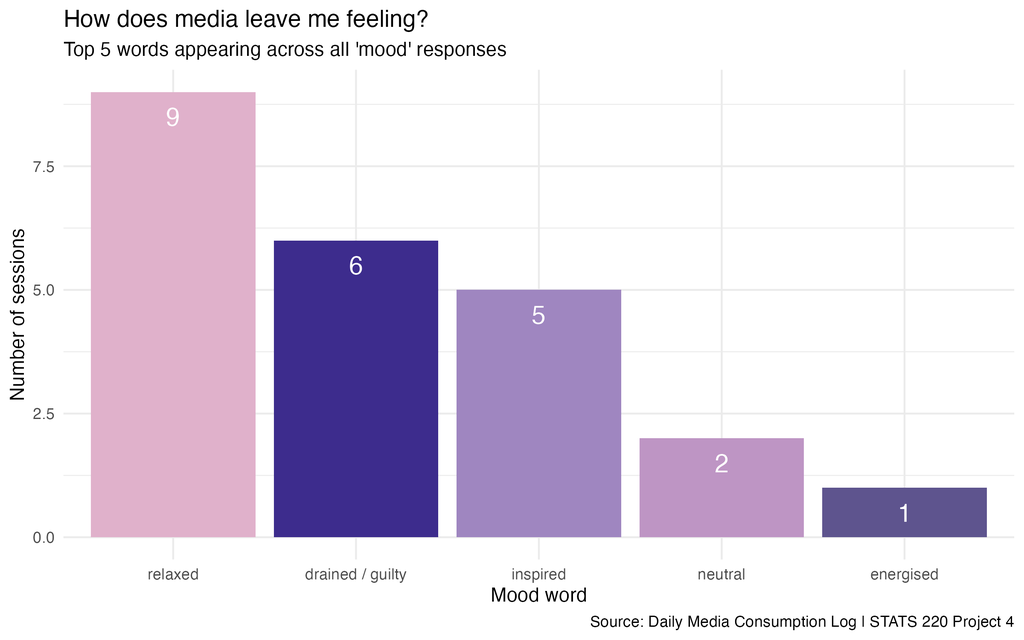

Bar chart of the top five words across all mood responses, each bar labelled with its count.

The dominant words say more about my media consumption than any minute count could. *Drained* and *guilty* show up disproportionately, and almost always next to late-night short-form sessions. *Inspired* and *energised* are rarer but tied tightly to deliberate, daytime use. The takeaway: *the way I feel after media has less to do with the content and more to do with whether I chose it.*

## So what?

Doing this project changed how I look at my phone, and really showed me how the minutes add up. What was useful was being forced to *log* before I could *plot*, and noticing the choice in real time, several times a day, for two weeks.

If you’re reading this, I hope you take this as a sign to reconsider your screen time, and how it may be affecting you.